## Part 1: Simulation Exercise Instructions

In this project you will investigate the exponential distribution in R and compare it with the Central Limit Theorem. The exponential distribution can be simulated in R with rexp(n, lambda) where lambda is the rate parameter. The mean of exponential distribution is 1/lambda and the standard deviation is also 1/lambda. Set lambda = 0.2 for all of the simulations. You will investigate the distribution of averages of 40 exponentials. Note that you will need to do a thousand simulations.

Illustrate via simulation and associated explanatory text the properties of the distribution of the mean of 40 exponentials. You should

**1. Show the sample mean and compare it to the theoretical mean of the distribution.** First we create a thousand simulations of the 40 exponentials and calculate and store their means.

```r
set.seed(1928)
lambda = 0.2
n = 40
nsim=1000

sims <- data.frame(mean=numeric(nsim))

for (i in 1 : nsim) {
  sample <-  rexp(n,lambda)
  sims[i,1] <- mean(sample)
}
```

```r
tmean = 1/lambda
smean <-mean(sims$mean)
```

Sample mean : 5.0209585 Theoretical mean: 5

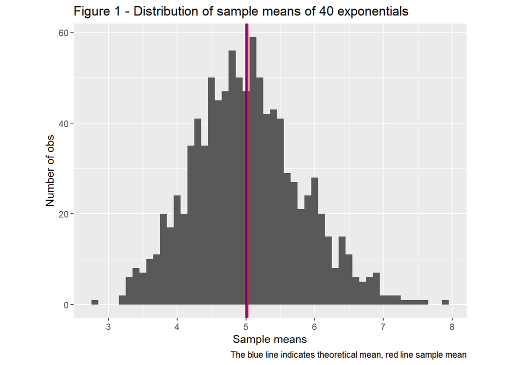

The histrogram show how close theoretical and sample mean are.

**2. Show how variable the sample is (via variance) and compare it to the theoretical variance of the distribution.**

We know that theoretical standard deviation is 1/lambda, so theoretical variance is 1/lambda^2

```r
tvar <-  (1/lambda^2)/n
tvar
```

```
## [1] 0.625
```

```
Then we calculate de sample variance as the variance of the means.
```

```r
svar <- var(sims$mean)
svar
```

```
## [1] 0.6276333
```

As we can see theoretical variance and sample variance are also very close.

**3. Show that the distribution is approximately normal.** In order to compare the distribution of averages of samples with a normal distribution with theoretical mean and standard deviation.

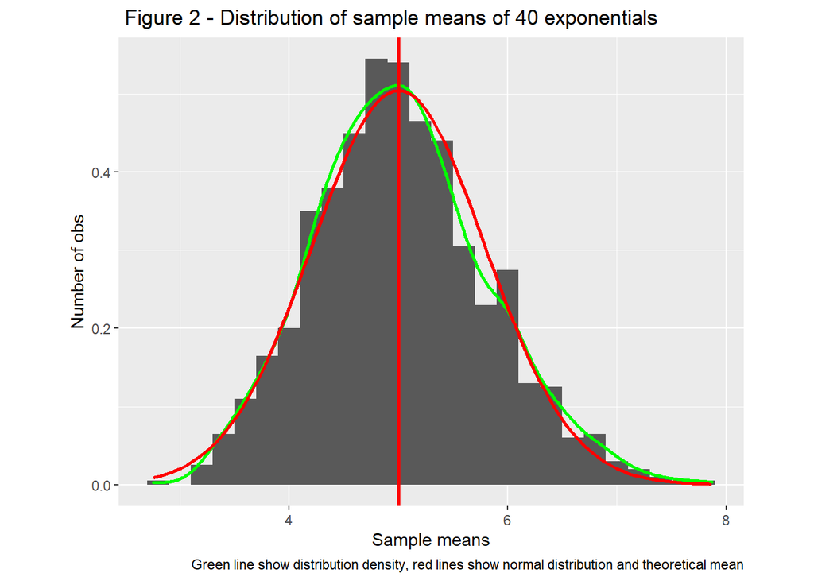

## Appendix - R Code

```r
# Figure 1 code

g <- ggplot(sims, aes(x=mean))
g <- g + geom_histogram(binwidth=0.1)
g <- g + labs(y = "Number of obs", x = "Sample means",
              title ="Figure 1 - Distribution of sample means of 40 exponentials" ,
              caption ="The blue line indicates theoretical mean, red line sample mean")
g <- g + geom_vline(xintercept=tmean,  color = "blue", size=1)
g <- g + geom_vline(xintercept=smean,  color = "red", size=1)
g
```

```r
# Figure 2 code

ggplot(sims, aes(x=mean)) +
      labs(y = "Number of obs", x = "Sample means",
            title =" Figure 2 - Distribution of sample means of 40 exponentials" ,
            caption ="Green line show distribution density,
                     red lines show normal distribution and theoretical mean") +
      geom_histogram(aes(y=..density..), size=1, binwidth=0.2) +
      geom_density(color="green", size=1) +
      stat_function(fun=dnorm, args=list(mean=tmean, sd=sqrt(tvar)), color = "red", size=1) +
      geom_vline(xintercept=tmean, color="red", size=1)
```